```python
import numpy as np
import pandas as pd
import geopandas as gpd
from matplotlib import pyplot as plt
from scipy.stats import linregress
from shapely import LineString, plotting
```

# Theoretical Basis for Length Scaling

## Overview

We assume that the Horton ratios calculated by (Boyd & Allen, 2025) reflect the geomorphic structure of the river network because they were calculated on NHDPlusV2 flowlines, which primarily represent perennially flowing reaches not subject to extension. Because NHDPlusV2 flowlines do not represent the absolute smallest streams in the network (Benstead & Leigh, 2013; Boyd & Allen, 2025) extrapolated their calculated Horton ratios to the true hydrologic 1st order. Necessary to this extrapolation is the assumption that the network is scale-invariant: the geomorphic structure of the smallest reaches of the network reflects that of the largest reaches. We make the same assumption.

These are the Horton ratios from (Boyd & Allen, 2025). $$ n(\omega) = ab^{\omega}$$ $$ \bar{l}(\omega) = cd^{\omega} $$

$ n(\omega) $ represents the number of streams of a particular Strahler order, $ \bar{l}(\omega) $ represents the mean length of the streams of a particular order, and $ \omega $ represents the order. $ a $, $ b $, $c$, and $d$ are fitted constants. For any stream order $ \omega $, the links of $ \omega + 1 $ will be $ b $ times as numerous and have $ d $ times the average length. In practice, $ b = 0.25 $ and $ d = 2.225 $, so $ \omega + 1 $ has $ 1/4 $ times the number of streams of $ \omega $, while those less numerous streams are $ 2.225 $ times the length. This scaling applies across the network irrespective of stream order. As hydrologic conditions change, the network extends or contracts, and stream orders are reassigned. The lengths and abundances of valleys don't change, nor do the locations of confluences. Thus, regardless of whether a set of links is order 3 or order 6 depending on the flow conditions, its number and average length scale predictably by the same factor to the next up- and downstream orders.

$ n(\omega) $ and $ \bar{l}(\omega) $ can be combined into a single law representing total length per stream order. $$ l(\omega) = n(\omega) \bar{l}(\omega) = ac(bd)^\omega = fg^\omega $$ We assume that at all flow conditions, the total network length is divided into stream order lengths which follow a scaling law of this form. Changes in total network length can be accomodated by varying any or all of $f$, $g$, or the maximum stream order. The independent influence of each variable on the scaling behavior is shown below. The plots are not to scale; they meant to show the expected form but not exact magnitude of scaling. This scaling law is linear in semilog space. The slope is $ \log g $, and the y-intercept is $ \log f $. Slope $ \log g $ represents the geomorphic structure of the network and does not vary with flow.

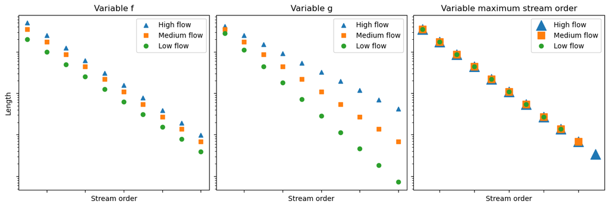

```python
# adjust f
high_orders_varf = np.arange(1, 11)
high_L_varf = (10000 * 0.5 ** high_orders_varf)

medium_orders_varf = np.arange(1, 11)
medium_L_varf = (7000 * 0.5 ** medium_orders_varf)

low_orders_varf = np.arange(1, 11)
low_L_varf = (4000 * 0.5 ** low_orders_varf)


# adjust g
high_orders_varg = np.arange(1, 11)
high_L_varg = (7000 * 0.6 ** high_orders_varg)

medium_orders_varg = np.arange(1, 11)
medium_L_varg = (7000 * 0.5 ** medium_orders_varg)

low_orders_varg = np.arange(1, 11)
low_L_varg = (7000 * 0.4 ** low_orders_varg)


# adjust max stream order
high_orders_varo = np.arange(1, 12)
high_L_varo = (7000 * 0.5 ** high_orders_varo)

medium_orders_varo = np.arange(1, 11)
medium_L_varo = (7000 * 0.5 ** medium_orders_varo)

low_orders_varo = np.arange(1, 10)
low_L_varo = (7000 * 0.5 ** low_orders_varo)

fig, (axf, axg, axo) = plt.subplots(ncols=3, figsize=(12, 4), constrained_layout=True, sharey=True)
axf.scatter(high_orders_varf, high_L_varf, marker='^', label='High flow')
axf.scatter(medium_orders_varf, medium_L_varf, marker='s', label='Medium flow')
axf.scatter(low_orders_varf, low_L_varf, label='Low flow')
axf.set_yscale('log')
axf.legend()
axf.set_xlabel('Stream order')
axf.set_ylabel('Length')
axf.tick_params(labelleft=False, labelbottom=False)
axf.set_title('Variable f')


axg.scatter(high_orders_varg, high_L_varg, marker='^', label='High flow')
axg.scatter(medium_orders_varg, medium_L_varg, marker='s', label='Medium flow')
axg.scatter(low_orders_varg, low_L_varg, label='Low flow')
axg.set_yscale('log')
axg.legend()
axg.set_xlabel('Stream order')
axg.tick_params(labelleft=False, labelbottom=False)
axg.set_title('Variable g')


axo.scatter(high_orders_varo, high_L_varo, label='High flow', marker='^', s=200)
axo.scatter(medium_orders_varo, medium_L_varo, label='Medium flow', marker='s', s=100)
axo.scatter(low_orders_varo, low_L_varo, label='Low flow')
axo.set_yscale('log')
axo.legend()
axo.set_xlabel('Stream order')
axo.tick_params(labelleft=False, labelbottom=False)
axo.set_title('Variable maximum stream order')
```

We propose that y-intercept $\log f$ and the maximum stream order vary with flow. That stream order is not static has been documented at the field scale (Godsey & Kirchner 2014). Wetting and drying of headwaters and the resulting stream order dynamics propagate downstream, causing the maximum stream order to vary. The following diagram represents the evolution of an extending headwater system. The western part of the network is static, and extension only occurs in the northern part. The upper panels are maps of the network, and the lower panels are scatter plots of length per stream order. Dotted lines on the map represent dry streams, and solid lines represent flowing streams. Width of solid lines scales with stream order. At t0 during low flow, only the lower part of geomorphic order 2 in the northern network is flowing. By the dynamic hydrologic ordering scheme, this is order 1. As flow increases from t0 to t1, the channel head migrates upward, and the length of order 1 increases. At t1, the entire lower valley is flowing. Further extension requires that the channel heads migrate upward into the two unwetted valleys. When this occurs at t2, the stream in the lower valley becomes hydrologic order 2, and the upper streams become order 1. The reordering propagates downstream, and the stream below the confluence becomes order 3. There exist very many headwater networks in the Mississippi Basin, all of which extend by headward migration to valley junctions followed by reordering. These changes do not occur in phase with each other. This would require that channel heads migrate upwards and reach valley junctions simultaneously. While some reaches are reordering, others in the network are migrating headward without reordering. When aggregated over very many headwaters, it follows that the lengths of individual stream orders increase with flow without necessarily reordering. This manifests in the scaling law as variable $f$ with flow.

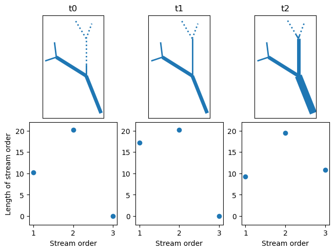

```python
fig, ((m0, m1, m2), (p0, p1, p2)) = plt.subplots(ncols=3, nrows=2, constrained_layout=True)
m0.set_aspect('equal')
m0.set_title('t0')
# m0.set_xlim(-5, 5)
# m0.set_ylim(-1, 16)
m0.set_xticks([])
m0.set_yticks([])
flowing_2_0_0 = LineString([(0, 0), (0, 3)])
flowing_2_0_1 = LineString([(0, 0), (-8, 5)])
flowing_1_0_0 = LineString([(-8, 5), (-8.5, 9)])
flowing_1_0_1 = LineString([(-8, 5), (-11, 4)])
flowing_2_0_2 = LineString([(4, -10), (0, 0)])

dry_2_0_0 = LineString([(0, 3), (0, 10)])
dry_1_0_0 = LineString([(0, 10), (-3, 15)])
dry_1_0_1 = LineString([(0, 10), (1.5, 14)])

plotting.plot_line(flowing_2_0_0, ax=m0, linestyle='solid', add_points=False)
plotting.plot_line(flowing_2_0_1, ax=m0, linestyle='solid', linewidth=5, add_points=False)
plotting.plot_line(flowing_1_0_0, ax=m0, linestyle='solid', add_points=False)
plotting.plot_line(flowing_1_0_1, ax=m0, linestyle='solid', add_points=False)
plotting.plot_line(flowing_2_0_2, ax=m0, linestyle='solid', linewidth=5, add_points=False)

plotting.plot_line(dry_2_0_0, ax=m0, linestyle='dotted', add_points=False)
plotting.plot_line(dry_1_0_0, ax=m0, linestyle='dotted', add_points=False)
plotting.plot_line(dry_1_0_1, ax=m0, linestyle='dotted', add_points=False)


p0.scatter(1, np.array([flowing_2_0_0.length, flowing_1_0_0.length, flowing_1_0_1.length]).sum(), c='tab:blue')
p0.scatter(2, np.array([flowing_2_0_1.length, flowing_2_0_2.length]).sum(), c='tab:blue')
p0.scatter(3, 0, c='tab:blue')
# p0.set_xlim(0, 3)
p0.set_ylim(-2, 22)
p0.set_xlabel('Stream order')
p0.set_ylabel('Length of stream order')

m1.set_aspect('equal')
m1.set_title('t1')
# m1.set_xlim(-5, 5)
# m1.set_ylim(-1, 16)
m1.set_xticks([])
m1.set_yticks([])

flowing_2_1_0 = LineString([(0, 0), (0, 10)])
flowing_1_1_0 = LineString([(-8, 5), (-8.5, 9)])
flowing_1_1_1 = LineString([(-8, 5), (-11, 4)])
flowing_2_1_1 = LineString([(0, 0), (-8, 5)])
flowing_2_1_2 = LineString([(4, -10), (0, 0)])

dry_1_1_0 = LineString([(0, 10), (-3, 15)])
dry_1_1_1 = LineString([(0, 10), (1.5, 14)])

plotting.plot_line(flowing_2_1_0, ax=m1, linestyle='solid', add_points=False)
plotting.plot_line(dry_1_1_0, ax=m1, linestyle='dotted', add_points=False)
plotting.plot_line(dry_1_1_1, ax=m1, linestyle='dotted', add_points=False)
plotting.plot_line(flowing_1_1_0, ax=m1, linestyle='solid', add_points=False)
plotting.plot_line(flowing_1_1_1, ax=m1, linestyle='solid', add_points=False)
plotting.plot_line(flowing_2_1_1, ax=m1, linestyle='solid', linewidth=5, add_points=False)
plotting.plot_line(flowing_2_1_2, ax=m1, linestyle='solid', linewidth=5, add_points=False)


p1.scatter(1, np.array([flowing_2_1_0.length, flowing_1_1_0.length, flowing_1_1_1.length]).sum(), c='tab:blue')
p1.scatter(2, np.array([flowing_2_1_1.length, flowing_2_1_2.length]).sum(), c='tab:blue')
p1.scatter(3, 0, c='tab:blue')
# p1.set_xlim(0, 3)
p1.set_ylim(-2, 22)
p1.set_xlabel('Stream order')


m2.set_aspect('equal')
m2.set_title('t2')
# m2.set_xlim(-5, 5)
# m2.set_ylim(-1, 16)
m2.set_xticks([])
m2.set_yticks([])
flowing_2_2_0 = LineString([(0, 0), (0, 10)])
flowing_1_2_0 = LineString([(0, 10), (-3/5, 10+5/5)])
flowing_1_2_1 = LineString([(0, 10), (1.5/5, 10+4/5)])
flowing_1_2_2 = LineString([(-8, 5), (-8.5, 9)])
flowing_1_2_3 = LineString([(-8, 5), (-11, 4)])
flowing_2_2_1 = LineString([(0, 0), (-8, 5)])
flowing_3_2_0 = LineString([(4, -10), (0, 0)])
dry_1_2_0 = LineString([(-3/5, 10+5/5), (-3, 15)])
dry_1_2_1 = LineString([(1.5/5, 10+4/5), (1.5, 14)])

plotting.plot_line(flowing_2_2_0, ax=m2, linestyle='solid', linewidth=5, add_points=False, label='Order 2')
plotting.plot_line(flowing_1_2_0, ax=m2, linestyle='solid', add_points=False, label='Order 1')
plotting.plot_line(flowing_1_2_1, ax=m2, linestyle='solid', add_points=False)
plotting.plot_line(dry_1_2_0, ax=m2, linestyle='dotted', add_points=False, label='Dry')
plotting.plot_line(dry_1_2_1, ax=m2, linestyle='dotted', add_points=False)
plotting.plot_line(flowing_1_2_2, ax=m2, linestyle='solid', add_points=False)
plotting.plot_line(flowing_1_2_3, ax=m2, linestyle='solid', add_points=False)
plotting.plot_line(flowing_2_2_1, ax=m2, linestyle='solid', linewidth=5, add_points=False)
plotting.plot_line(flowing_3_2_0, ax=m2, linestyle='solid', linewidth=10, add_points=False)


p2.scatter(1, np.array([flowing_1_2_0.length, flowing_1_2_1.length, flowing_1_2_2.length, flowing_1_2_3.length]).sum(), c='tab:blue')
p2.scatter(2, np.array([flowing_2_2_0.length, flowing_2_2_1.length]).sum(), c='tab:blue')
p2.scatter(3, np.array([flowing_3_2_0.length]).sum(), c='tab:blue')

p2.set_ylim(-2, 22)
p2.set_xlabel('Stream order')
```

With variable $f$ and maximum stream order and constant $g$, the following behavior is expected.

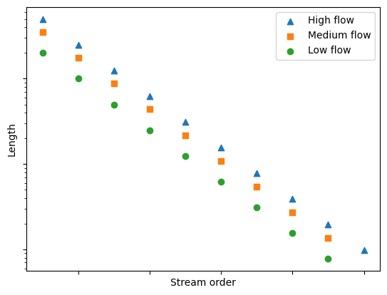

```python
high_orders = np.arange(1, 11)
high_L = (10000 * 0.5 ** high_orders)

medium_orders = np.arange(1, 10)
medium_L = (7000 * 0.5 ** medium_orders)

low_orders = np.arange(1, 10)
low_L = (4000 * 0.5 ** low_orders)


fig, ax = plt.subplots()
ax.scatter(high_orders, high_L, marker='^', label='High flow')
ax.scatter(medium_orders, medium_L, marker='s', label='Medium flow')
ax.scatter(low_orders, low_L, label='Low flow')
ax.set_yscale('log')
ax.legend()
ax.set_xlabel('Stream order')
ax.set_ylabel('Length')
ax.tick_params(labelleft=False, labelbottom=False)
```

## Flow accumulation thresholds

| Variable | Value |
| --- | --- |
| $L$ | Calculated catchment network length |
| $L_{NHD}$ | Catchment network length measured from NHD |
| $Q$ | Discharge |
| $\beta$ | Network extension exponent (Godsey & Kirchner 2014; Prancevic & Kirchner 2019; Prancevic et al 2025) |
| $\alpha$ | Drainage area accumulation exponent (Prancevic & Kirchner 2019; Prancevic et al 2025) |
| $A$ | Drainage area |

We seek to validate this behavior using two approaches. Necessary to both approaches are flow accumulation thresholds. Corresponding to each of 10 flow deciles, we derive 10 flow accumulation thresholds from the topographic parameters by (Prancevic et al 2025). Catchment network length scales as $L \propto Q^\beta$ (Godsey & Kirchner 2014). We assume that length mapped in NHD corresponds to median discharge from GRADES-DL (Yang et al 2025) and fit the $\log(Q) \propto \beta\log(L)$ line through the point $(\log(L_{NHD}), \log(Q_{med}))$ to give a definite relationship between length and discharge: $$\log(L) = \beta(\log(Q)-\log(Q_{med})) + \log(L_{NHD})$$

This relationship is a jump beyond existing literature on stream extension, which has historically focused on $\beta$. We apply this relationship to flow deciles to get length at each flow level. A similar derivation is used to calculate drainage area at the channel head. The $\alpha$ parameter provided by (Prancevic et al 2025) describes how drainage area accumulates in the downstream direction with this relationship: $L \propto A^{-\alpha}$. In other words, moving up the network from valley to hillslope, drainage area goes as a power law of $L^{-1/\alpha}$. We anchor the length-drainage area relationship in a similar way using a known point. The (Prancevic et al 2025) dataset includes values for minimum and maximum calculated drainage density and mimimum and maximum calculated channel head area, which are used in their elasticity analysis. We fit $A \propto L^{-1/\alpha}$ through the point $(L_{max}, A_{min})$ to get the next relationship: $$\log(A) = -(\frac{1}{\alpha})(\log(L) - \log(L_{max})) + \log(A_{min})$$ The decile lengths calculated from the length-discharge equation are fed into the area-length equation to calculate flow accumulation thresholds per catchment per flow decile.

## MERIT Hydro network approach

For each of 10 flow deciles, we extract river networks from the MERIT Hydro rasters (Yamazaki et al 2019). We assign stream orders and sum the length per stream order. For the lowest stream orders, $ l(\omega) $ scales as expected. At all flows, the $ l(\omega) $ curves have roughly equal slopes. The relationships deteriorate for high stream orders due to (1) finite size effects deflating the abundance of high-order streams and (2) a relatively small number of long streams being dynamically reordered. One drawback of this approach is the spatial resolution of the rasters (90 m). Some per-catchment flow accumulation thresholds derived from (Prancevic et al 2025) produce a network with finer drainage density than can be represented with this spatial resolution. We instead use the median accumulation threshold per flow decile rather than per-catchment values. This approach cannot account for geographic varability in network elasticity or drainage density.

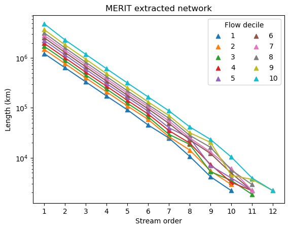

```python
meritlens = pd.read_csv('merit_lendf_20260616.csv')
meritlens = meritlens.loc[meritlens['length_km'] > 1]

fig, ax = plt.subplots()

for Qd, df in meritlens.groupby('Q_decile'):
    ax.scatter(df['order'], df['length_km'], label=Qd + 1, marker='^')
    ax.plot(df['order'], df['length_km'])

ax.legend(title='Flow decile', ncols=2)
ax.set_yscale('log')

ax.set_xlabel('Stream order')
ax.set_ylabel('Length (km)')

ax.set_xticks(np.arange(1, 13, 1))
ax.set_title("MERIT extracted network")
```

## Hydrosheds v2 vector trimming approach

Next, we validate the theory by trimming the uppermost reaches from the Hydrosheds v2 vector network. Hydrosheds v2 reaches have a flow accumulation threshold of ~ 1 km<sup>2</sup>, which is far larger than the derived flow accumulation thresholds. We trim the vector network for each of 10 flow levels. To do this we overlay the catchment polygons with flow accumulation attributes on the network vector product with a drainage area attribute. For each flow decile, the network is filtered to remove reaches whose drainage area is less than 50x the overlying catchment's corresponding flow accumulation threshold. 50x flow accumulation was selected to maximize the available data while still capturing "full" network dynamics. In tests where the network was trimmed by 10x flow accumulation, in many cases the 8th decile network was expected to have a higher drainage density than Hydrosheds v2 offers, so the highest-flow networks were expected to be longer than the untrimmed Hydrosheds v2 network. Because this approach does not involve generating any new flowlines (and it cannot until flow accumulation rasters in units of area rather than pixels are released), applying this method with 10x flow accumulation cannot produce network extension across the full range of flows.

Though the resultant networks are substantially smaller than those derived from DEMs, this approach is still valid given the scale-invariance of river networks. The results of this approach are broadly similar to those of the network extraction from MERIT rasters. At low stream orders, $ \log {L(\omega)} $ scales linearly with $ \omega $ with the same slope regardless of flow. The clean relationship breaks down at high orders due to dynamic reordering and finite size effects.

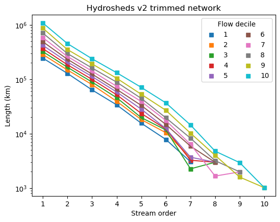

```python
hydroshedslens = []

Qds = range(10)
base = r'hydrosheds_lengths\200260719_hydrosheds_lengths_'

for Qd in Qds:
    ldf = pd.read_csv(f'{base}{Qd}_ah50.csv')
    hydroshedslens.append(ldf)

hydroshedslens = pd.concat(hydroshedslens)
hydroshedslens = hydroshedslens.drop('Unnamed: 0', axis=1)

fig, ax = plt.subplots()

for Qd, df in hydroshedslens.groupby('Q_decile'):
    ax.scatter(df['order'], df['length_km'], label=Qd + 1, marker='s')
    ax.plot(df['order'], df['length_km'])

ax.set_yscale('log')
ax.legend(title='Flow decile', ncols=2)
ax.set_xlabel('Stream order')
ax.set_ylabel('Length (km)')
ax.set_xticks(np.arange(1, 11, 1))
ax.set_title('Hydrosheds v2 trimmed network')
```

Overlaying both on the same plot:

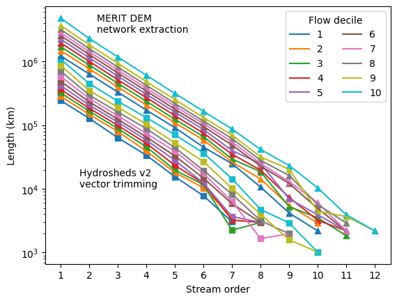

```python
fig, ax = plt.subplots()

for Qd, df in hydroshedslens.groupby('Q_decile'):
    ax.scatter(df['order'], df['length_km'], marker='s')
    ax.plot(df['order'], df['length_km'], label=Qd + 1)

for Qd, df in meritlens.groupby('Q_decile'):
    ax.scatter(df['order'], df['length_km'], marker='^')
    ax.plot(df['order'], df['length_km'])

ax.set_yscale('log')
ax.legend(title='Flow decile', ncols=2)

ax.set_xlabel('Stream order')
ax.set_ylabel('Length (km)')
ax.set_xticks(np.arange(1, 13, 1))

ax.text(x=0.15, y=0.9, s='MERIT DEM\nnetwork extraction', transform=ax.transAxes)
ax.text(x=0.1, y=0.3, s='Hydrosheds v2\nvector trimming', transform=ax.transAxes)
```

## Theoretical stream order assignment

| Variable | Value |
| --- | --- |
| $\omega$ | Strahler stream order |
| $\omega_{max}$ | Highest strahler stream order |
| $l(\omega)$ | Length of a particular stream order |
| $L$ | Total network length |
| $f$ | Fitted constant |
| $g$ | Ratio of $ l(\omega + 1) $ to $ l(\omega) $ |

The conceptual method was developed by a human. The mathematical details of the optimization and the function `solve_f_and_n` were written by a large language model and checked by a human.

The optimization follows these steps:

### Step 1

From the given length of the highest stream order, the total length of the network, and the g value, what is the highest stream order in the network? This step does not necessarily produce a whole number because it is highly improbable that each stream order is exactly $g$ times the length of the next and that the sum of the lengths exactly equals the expected total network length. Fractional stream orders don't make sense, so we round the calculated highest stream order to the nearest integer.

Derivation of stream order:

$ L = \sum_{\omega=1}^{\omega_{max}} fg^{\omega} $ is a geometric series. For $ g \neq 1 $, the series can be rewritten as $$ S = \sum_{\omega=1}^{\omega_{max}} fg^{\omega} = fg \frac{1-g^{\omega_{max}}}{1-g} $$ The length of the highest stream order is given by $$ l(\omega_{max}) = fg^{\omega_{max}} $$

f is isolated in the equation for the length of the highest stream order. $$ f = \frac{l(\omega_{max})}{g^{\omega_{max}}} $$

f is replaced in the summation. $$ L = g (\frac{l(\omega_{max})}{g^{\omega_{max}}}) \frac{1-g^{\omega_{max}}}{1-g} $$

Simplify. $$ L = l(\omega_{max})\frac{g^{1 - \omega_{max}} - g}{1-g} $$

$\omega_{max}$ must be isolated. $$\frac{L(1-g)}{l(\omega_{max})} + g = g^{1-\omega_{max}} $$

Log pulls $\omega_{max}$ out of the exponent. $$ \log_g(\frac{L(1-g)}{l(\omega_{max})} + g) = 1 - \omega_{max} $$

### Step 2

Then, using the rounded $\omega_{max}$, we calculate $f$ by rearranging the geometric sum as $$ f = \frac{L(1-g)}{g(1-g^{\omega_{max}})} $$ Results of optimizing $ f$ and $\omega_{max}$ follow.

```python
# total network length
catchments = gpd.read_file(r'C:\Users\dego\Documents\local_files\big_datasets\Prancevic_et_al_2025\sheds_w_nhd_merit_atts_ahthresh.gpkg')

catchments = catchments.loc[catchments['beta'] > 0.0001]
catchments = catchments.loc[catchments['beta'] < 1]

Qps = np.arange(5, 105, 10)

# active network length
anl_list = np.array([np.sum(catchments[f'len{p:02}']) for p in Qps])

for n in range(len(Qps)):
    p = Qps[n]
    l = anl_list[n]

    print(f'{p} percentile: {l:.02f} m')
```

```
5 percentile: 2670995.05 m
15 percentile: 3078735.30 m
25 percentile: 3433576.11 m
35 percentile: 3825933.33 m
45 percentile: 4291399.48 m
55 percentile: 4819918.00 m
65 percentile: 5452130.82 m
75 percentile: 6286492.98 m
85 percentile: 7586915.53 m
95 percentile: 10625913.33 m
```

```python
# optimize f and max order to fit known g, length per max order, and total network length
def solve_f_and_n(g: float, S: float, Y: float):
    """
    Solve for f and n given:
        L(omega) = f * g**x,  x = 1, 2, ..., n
        S = sum_{x=1}^{n} y(x)   (known total network length)
        Y = y(n)                 (known value at the highest stream order)

    Returns
    -------
    n_hat   : int     n rounded to the nearest natural number
    f_sum   : float   f recomputed from the sum condition using n_hat (alternative)
    """

    if g <= 0:
        raise ValueError("g must be positive for the log formula to be real-valued.")

    if g == 1:
        # Degenerate case: y(x) = f for all x
        n_exact = S / Y
        n_hat = max(1, round(n_exact))
        f_sum = S / n_hat
    else:
        inner = S * (1 - g) / Y + g
        if inner <= 0:
            raise ValueError(
                "Invalid inputs: log argument is non-positive "
                f"(computed inner={inner}). Check S, Y, g for consistency."
            )
        n_exact = 1 - np.log10(inner) / np.log10(g)
        n_hat = max(1, round(n_exact))

        # compute f after rounding n (max order) to integer
        f_sum = S * (1 - g) / (g * (1 - g**n_hat)) if n_hat > 0 else float('nan')

    return n_hat, f_sum
```

```
f = 3850371072.0000
g = 0.5563
```

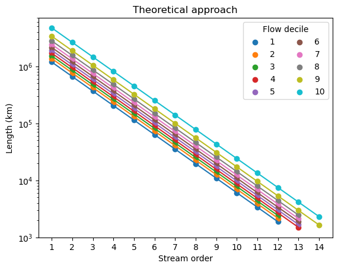

```python
a = 67108864
b = 0.25
c = 57.375
d = 2.225

f = a * c
g = b * d

print(f'f = {f:.04f}')
print(f'g = {g:.04f}')

flist = [None] * 10
max_orders = [None] * 10
active_network_order_dfs = [None] * 10


for n in range(len(anl_list)):
    anl = anl_list[n]
    Y = 1_879      # known value at x = n (the last term)
    n_hat, f_sum = solve_f_and_n(g, anl, Y)
    max_order = n_hat
    f = f_sum

    orders = np.arange(1, max_order + 1)
    lengths = f * (g ** orders)
    active_network_order_dfs[n] = pd.DataFrame({'order': orders, 'length_km': lengths, 'Q_decile': np.array([n] * len(orders))})

active_order_df = pd.concat(active_network_order_dfs)
active_order_df.to_csv('lengths_approach5_20260722.csv')

fig, ax = plt.subplots()
ax.set_yscale('log')
for Qd, df in active_order_df.groupby('Q_decile'):
    ax.scatter(df['order'], df['length_km'], label=Qd + 1)
    ax.plot(df['order'], df['length_km'])

ax.set_xlabel('Stream order')
ax.set_ylabel('Length (km)')
ax.legend(title='Flow decile', ncols=2)
ax.set_xticks(np.arange(1, 15, 1))
ax.set_title('Theoretical approach')
```